# Part II - ANALYZING FORD GOBIKE SYSTEM DATA

## by Jorge Muñoz Rama

## Investigation Overview

> This analysis focuses on the FordGoBike system in the San Francisco Bay Area and tries to find out when (days and hour of the day) the most trips take place and their duration, as well as where those bike stations are located. Taking into account the characteristics of the travelers (gender, year of birth and type of user).

## Dataset Overview

> The data belongs to the FordGoBike system located in the Bay Area. The dimension of the original data is 183,412 rows by 16 columns. It collects data almost exclusively for the month of February 2019. Variables present in the data include: The start and end times of the trips, the duration in seconds, the start and end stations with their names; the latitude and longitude of these stations, the type of user as well as their gender. Some variables presented a small percentage (0.11%) of NaN as was the case of the variables of start and end of the station and variables such as year of birth and gender with 4.72% of NaN. Year of birth also presented abnormal values as born even before 1900.

## Map showing all the FordGoBike stations in the San Francisco Bay Area.

The data set has 329 stations located in the Bay Area of San Francisco. There are clearly three groups of stations, two of them are located at both side of the bridge and the other in San Jose. You can clik in the blue point to see the name of the station.

Make this Notebook Trusted to load map: File -> Trust Notebook

[interactive chart not shown]

## The top 10 stations with the highest total number of trips.

Market St at 10th ST has more rides in total, follow by San Francisco Caltrain Station 2 and Berry St at 4th St. The graph only considers the total number of trips (start points).

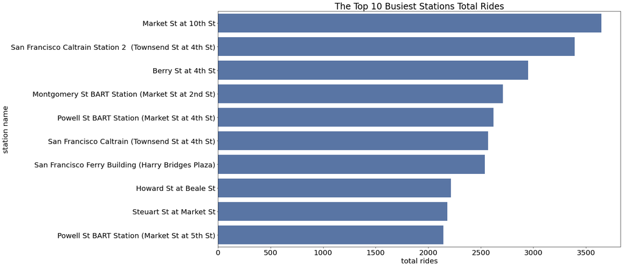

## Total Bike Rides by days and by hours

Thursday has more total trips, followed by Tuesday and Wednesday. There is a significant decrease in the number of trips on weekends.  
Five in the afternoon and eight in the morning present the highest number of total trips.

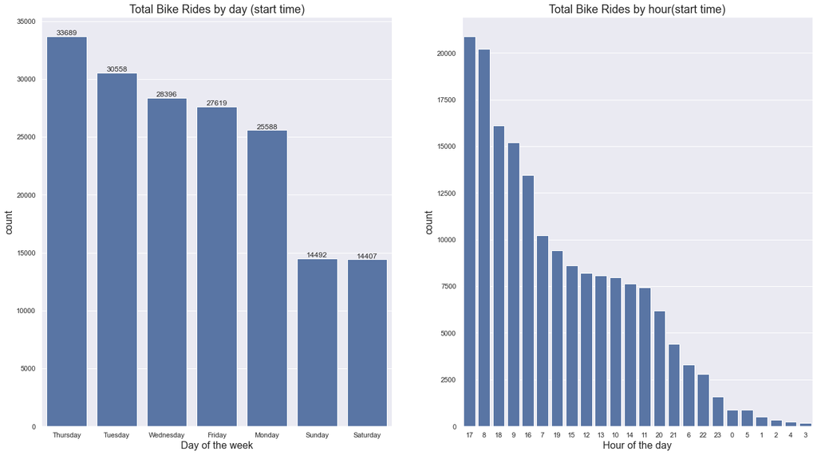

# Number of trips by type of user and by type of customer.

The subscriber group (91%) has almost ten times more total trips than the cutomer group. As we have already seen, the most used hours for the service are 8 am and 5 pm, which indicates that a high percentage of subscribers use the service during business hours. In the distribution between genders we see that the total trips of Men (75%) is three times that of women (23%), while the other gender (2%) is a small fraction of the total number of trips.

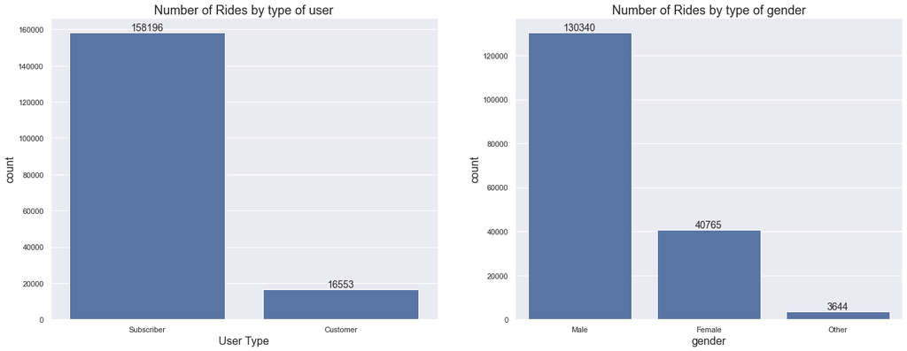

## Porcentage the number of rides by gender and user type

75% of the total rides was made by Male, 23 % by Femele and 2% by other. The subscribers are the 91% of the total user type.

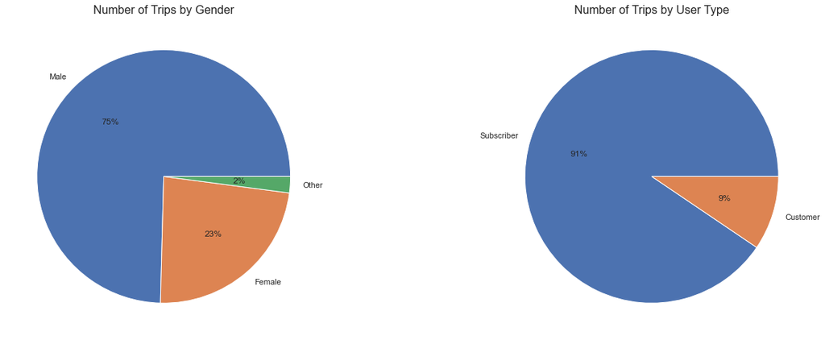

## Histogram birth of year by total number of rides.

The data is left skewed with the mean of the year of birth equal 1984. When we cleaned the data we drop year of birth before 1940 because we considered them as outliers in our analysis.

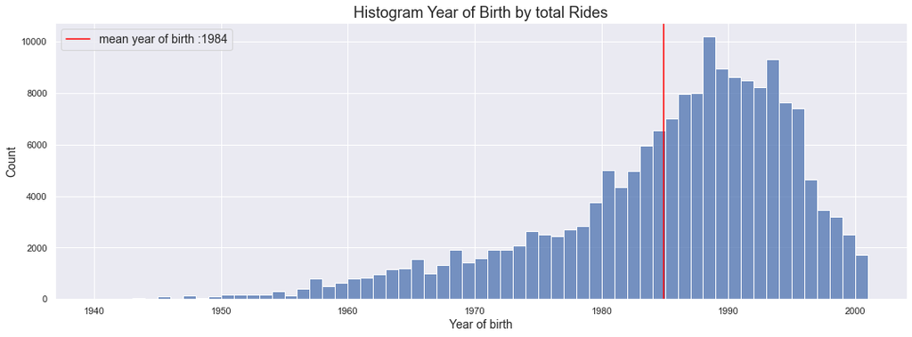

## Histogram duration in minutes.

The distribution in duration in minutes is right skewed where 11.74 minutes is the avarege by ride. We have represented values from cero to one hundred in the plot.

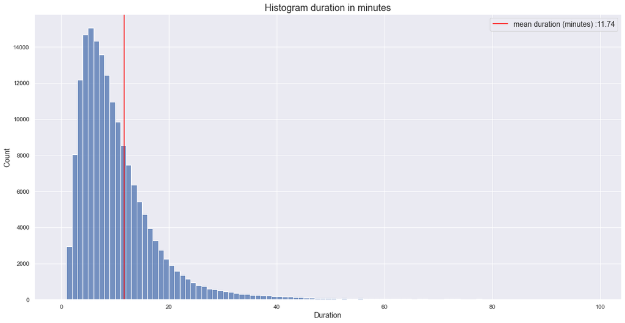

## Mean duration by day of the week

Trips on Sunday and Saturday have the longest average duration in minutes. We have seen that there were fewer trips on weekends than on weekdays. It seems that people spend more time on the weekends probably just for fun and sightseeing.

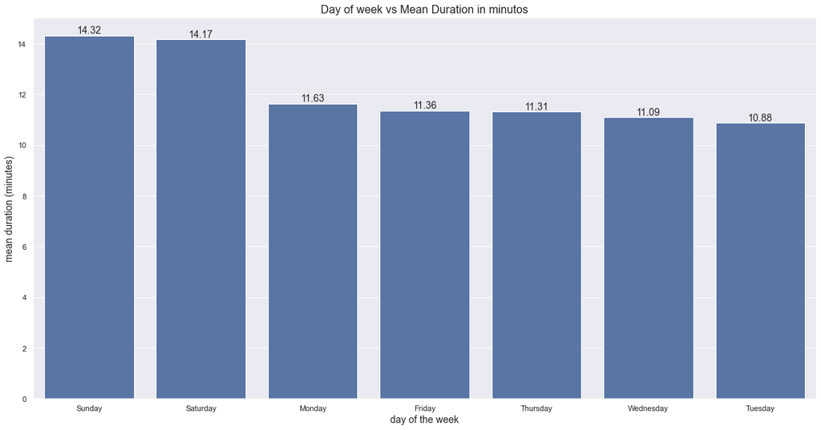

## Boxplot about the duration of the rides by user type and gender

We see that the customer spends more time per trip on average than the subscriber. The difference in the mean duration by gender is minimal. We can see a lot of the outlier too. The graph shows durations less than or equal to 100 minutes.

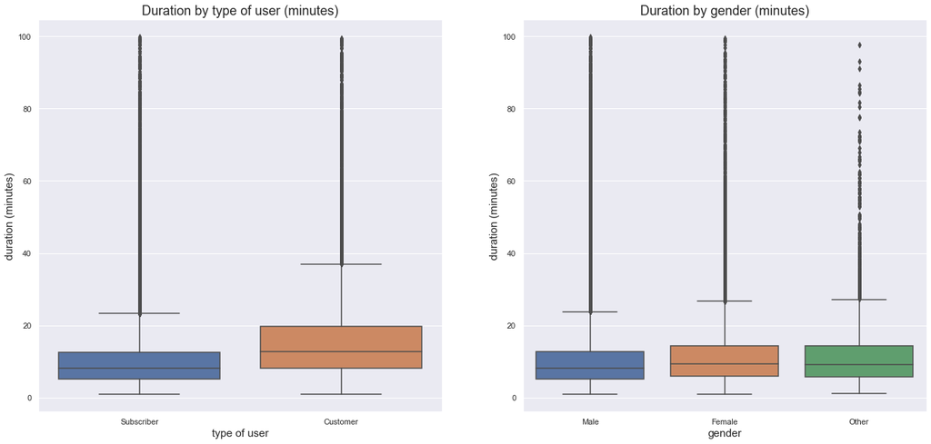

## Hourly total trips by user type

We see that the distribution of the Suscribers has a flat zone in the number of trips between the 10 and 15 hours and two clear peaks (bimodal) that which coincides with working hours. In the case of Customer doesn't have a clear flat zone in the number of trips.

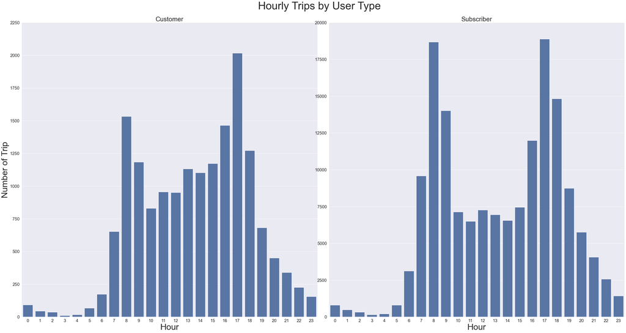

## Mean Duration by day of the week and user type

The average duration is longer every day of the week in the Customer Group, with a significant increase at the weekend. The group of subscribers the average duration remains practically the same every day with a small increase in the weekend. We use duration time less or equal to one hundred minutes.

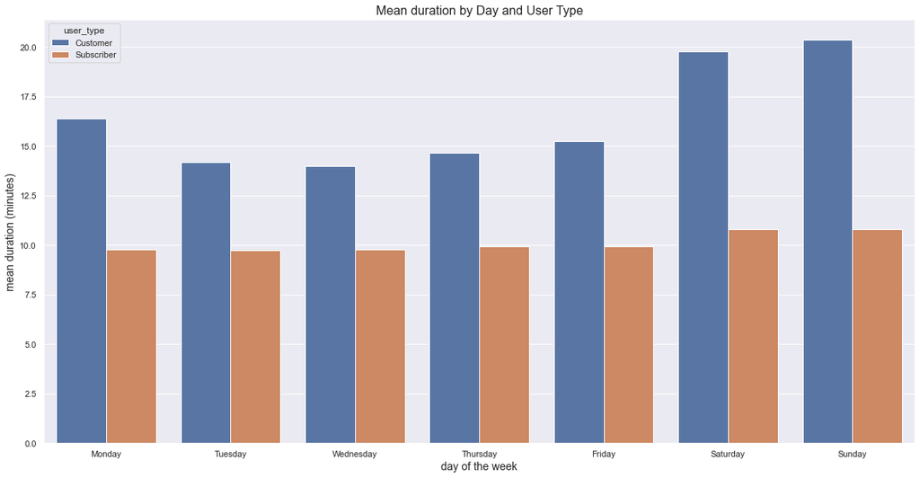

### The top 3 Busiest Stations by day of the week.

We can say that San Francisco Caltrain Station 2 is the busiest station from Monday to Thursday, but on Fridays Market St at 10th St stations is busiest and on weekends too. The first place of Market St at 10th St in total amout of rides shwon in the previuos plot that can be explain because the increse of the bike rides on the weekends.

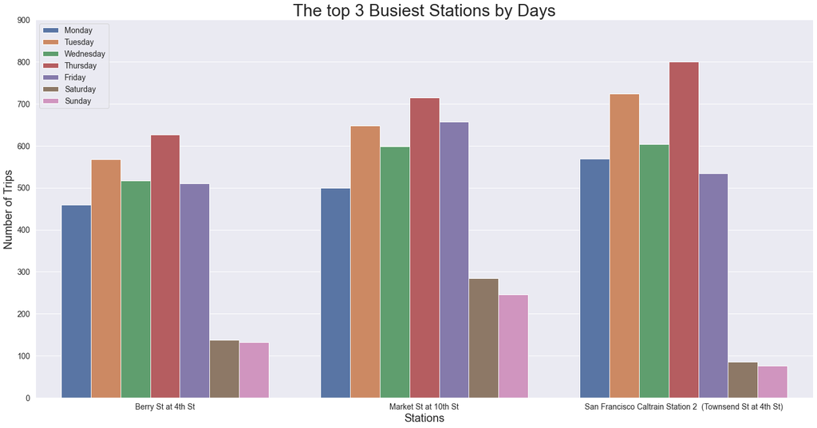

## Average duration by day of the week and user type

Firstly, the two groups show an increase in the average duration of the trips during the weekend. The customer group has a much higher average in the duration of the travel than the subscriber group. This can be explained if we assume that subscribers usually use the bicycle to go to work and customers use it to enjoy themselves.

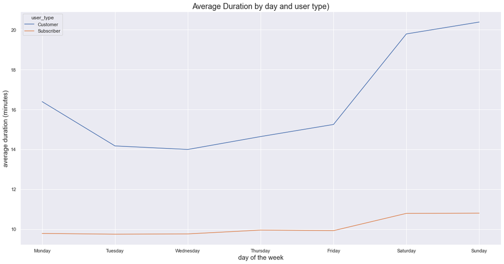

## Heatmap number of trips in fuction of day of the week and hour of the day.

We see that subscriber has more trips at 8:00 and at 17:00 from Monday to Friday and Saturday and Sunday decrese significantly the amount of rides at any time, on the contrary Customer has a lot of activite on weekend specialy between 10:00 to 17:00.

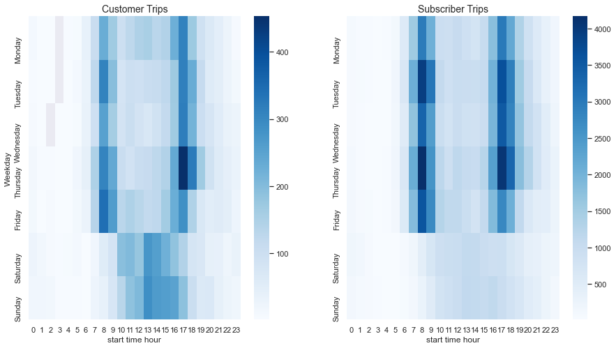